# Bayesian hierarchical modelling by hand

Bruna Wundervald

October, 2020

[figure not shown]

[Bruna Wundervald](https://brunaw.com/)  
`brunadaviesw at gmail.com`  
PhD Candidate in Statistics, Hamilton Institute

# Model

Define the following model. Suppose we have data:
$$y_{ij}, i = 1,\ldots,n_j, \; j = 1\ldots, m$$
where $y_{ij}$ is observation $i$ in group $j$. There are different numbers of observations $n_j$ in each group, so for example $n_1$ is the number of observations in group 1, etc. There are $m$ groups. The total number of observations is $n = \sum_{j=1}^m n_j$

Suppose have a likelihood:
$$y_{ij} \sim N(\mu_j, \tau^{-1})$$

so each group has an overall mean $\mu_j$, with an overall precision term $\tau$.

We then have a hierarchical prior distribution:

$$\mu_j \sim N(\mu, \omega^{-1})$$

and hyper-parameter prior distributions:

$$\mu \sim N(\mu_\mu, \tau_\mu)$$
$$\tau \sim Ga(\alpha, \beta)$$
$$\omega \sim Ga(\alpha_\omega, \beta_\omega)$$

Where the values $\mu_\mu, \tau_\mu, \alpha, \beta, \alpha_\omega, \beta_\omega$ are all fixed.

## Maths

- Likelihood:

$$\begin{equation}
L = \prod_{j = 1}^{m} \prod_{i = 1}^{n_j} p(y_{ij} | \mu_{j}, \tau) \\
L \propto \tau^{n/2} exp \{ -\frac{\tau}{2} \sum_{j = 1}^{m}
\sum_{i = 1}^{n_j} (y_{ij} - \mu_j)^2 \}
\end{equation}$$

- $\mu_j | \mu, \omega$

$$\begin{equation}
p(\mu_1, \dots, \mu_m | \mu, \omega) \propto \omega^{m/2}
exp\{ - \frac{\omega}{2} \sum_{j = 1}^{m} (\mu_j - \mu)^2 \}
\end{equation}$$

- $\tau | \alpha, \beta$

$$p(\tau | \alpha, \beta) \propto \tau^{\alpha - 1} exp\{ - \beta \tau \}$$

- $\mu | \mu_{\mu}, \tau_{\mu}$

$$\begin{equation}
p(\mu | \mu_{\mu}, \tau_{\mu}) \propto \tau_{\mu}^{1/2}
exp\{ - \frac{ \tau_{\mu}}{2} (\mu - \mu_{\mu})^2 \}
\end{equation}$$

- $\omega$

$$p(\omega | \alpha_{\omega}, \beta_{\omega})
\propto \omega^{\alpha_{\omega} - 1} exp\{ - \beta_{\omega} \omega \}$$

- $p(\tau, \mu_1, \dots, \mu_m, \mu, \omega | y, \mu_{\mu}, \tau_{\mu}, \alpha, \beta, \alpha_{\omega}, \beta_{\omega})$

$$\begin{equation}
p(\tau, \mu_1, \dots, \mu_m, \mu, \omega | y, \mu_{\mu},
\tau_{\mu}, \alpha, \beta, \alpha_{\omega}, \beta_{\omega}) \propto
\tau^{\alpha - 1} exp\{ - \beta \tau \} \times
\omega^{m/2}
exp\{ - \frac{\omega}{2} \sum_{j = 1}^{m} (\mu_j - \mu)^2 \} \\
\times
\tau_{\mu}^{1/2}
exp\{ - \frac{ \tau_{\mu}}{2} (\mu - \mu_{\mu})^2 \} \times
\omega^{\alpha_{\omega} - 1} exp\{ - \beta_{\omega} \omega \} \\
\times \tau^{n/2} exp \{ -\frac{\tau}{2} \sum_{j = 1}^{m}
\sum_{i = 1}^{n_j} (y_{ij} - \mu_j)^2 \}
\end{equation}$$

## Posterior for $\tau$

- $p(\tau | \mu_1, \dots, \mu_m, y, \alpha, \beta)$

$$\begin{equation}
p(\tau | \mu_1, \dots, \mu_m, y, \alpha, \beta) \propto
\tau^{\alpha - 1} exp\{ - \beta \tau \} \times
\tau^{n/2} exp \{ -\frac{\tau}{2} \sum_{j = 1}^{m}
\sum_{i = 1}^{n_j} (y_{ij} - \mu_j)^2 \} \\
\propto \tau^{n/2 + \alpha - 1 }
exp \{ - \tau \Big( \frac{\sum_{j = 1}^{m}
\sum_{i = 1}^{n_j} (y_{ij} - \mu_j)^2}{2} + \beta \Big) \}
\end{equation}$$

So $\tau | \mu_1, \dots, \mu_m, y, \alpha, \beta \sim \text{Gamma}(n/2 + \alpha, \frac{\sum_{j = 1}^{m} \sum_{i = 1}^{n_j} (y_{ij} - \mu_j)^2}{2} + \beta)$

## Posterior for $\mu_j$

- I know I don’t have to use the joint distribution of $\mu_1, \dots, \mu_j$ for this but it seemed easier

$$\begin{equation}
Q = \omega \sum_{j=1}^{m} (\mu_j - \mu)^2 +
\tau \sum_{j = 1}^{m} \sum_{i = 1}^{n_j} (y_{ij} - \mu_j)^2 \\
Q = \omega \sum_{j=1}^{m} (\mu_j^{2} - 2 \mu \mu_j + \mu^2) +
\tau (\sum_{j = 1}^{m} (\sum_{i = 1}^{n_j} y_{ij}^{2} -
2 y_{ij} \mu_j) + n_j \mu_j^2) \\
Q = \sum_{j=1}^{m} (n_j \tau + \omega) \mu_j^2 -
\sum_{j = 1}^{m} (2 \mu \omega + 2 \bar y_j n_j \tau) \mu_j \\
Q = \sum_{j=1}^{m} [(n_j \tau + \omega) \mu_j^2 -
2 \mu_j(\mu \omega + \bar y_j n_j \tau) ] \\
Q \propto \sum_{j=1}^{m} [(n_j \tau + \omega)(\mu_j -
\frac{(\mu \omega + \bar y_j n_j \tau)}{(n_j \tau + \omega)})^2 ] \\
\end{equation}$$

So for each $\mu_j$

$$\mu_j | \mu, y, \tau, \omega \sim N( \frac{n_j \bar y_j \tau + \mu \omega}{n_j \tau + \omega}, (n_j \tau + \omega)^{-1})$$

## Posterior for $\mu$

Similarly, for $\mu$ we have:

$$\begin{equation}
Q = \omega \sum_{j = 1}^{m} (\mu_j - \mu)^2 + \tau_{\mu}(\mu - \mu_{\mu})\\
Q = \omega \sum_{j=1}^{m} (\mu_j^{2} - 2 \mu \mu_j + \mu^2) +
\tau_{\mu} (\mu^2 - 2 \mu \mu_{\mu} + \mu_{\mu}^2) \\
Q = (\tau_{\mu} + \omega m ) \mu^2 -
2 \mu (\omega \bar \mu m + \mu_{\mu} \tau_{\mu}) \\
Q \propto (\tau_{\mu} + \omega m )(\mu -
\frac{\omega \bar \mu m + \mu_{\mu} \tau_{\mu}}{\tau_{\mu} + \omega m})^2 \\
\end{equation}$$

So for $\mu$ we have that:

$$\mu | \mu_1, \dots, \mu_{m}, \mu_{\mu}, \tau_{\mu}, \omega \sim N(\frac{\omega \bar \mu m + \mu_{\mu} \tau_{\mu}}{\tau_{\mu} + \omega m} , (\tau_{\mu} + \omega m)^{-1})$$

## Posterior for $\omega$

$$\begin{equation}
p(\omega | \mu_1, \dots, \mu_m, \alpha_{\omega},
\beta{\omega}) \propto
\omega^{\alpha_{\omega} - 1} exp\{ - \beta_{\omega} \omega
\} \times
\omega^{m/2} exp \{ -\frac{\omega}{2} \sum_{j = 1}^{m}
(\mu_{j} - \mu)^2 \} \\
\propto \omega^{m/2 + \alpha_{\omega} - 1 }
exp \{ - \omega \Big( \frac{\sum_{j = 1}^{m}
(\mu_{j} - \mu)^2}{2} + \beta_{\omega} \Big) \}
\end{equation}$$

So $\omega | \mu_1, \dots, \mu_m, \alpha_{\omega}, \beta{\omega} \sim \text{Gamma}(m/2 + \alpha_{\omega}, \frac{\sum_{j = 1}^{m}(\mu_{j} - \mu)^2}{2} + \beta)$

## JAGS code

First we establish the maths involved in this model and simulate from it:

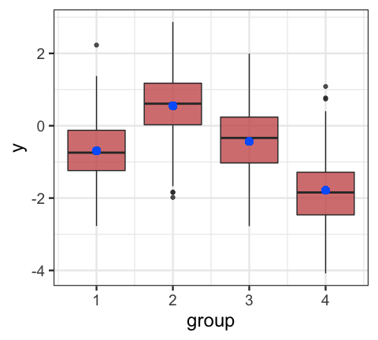

```r
library(R2jags)
library(tidyverse)

# Maths --------------------------------------------------------------

# Description of the Bayesian model fitted in this file
# Notation:
# y_{ij} = response variable for observation i = 1,...,n_j
# in group j = 1,..,M.
# N = total number of observation = sum_j(n_j)
# mu_j = mean for each group j
# mu = mean for mu_j
# tau = inverse variance of y_ij
# omega = inverse variance of mu_j

# Likelihood:
# y_{ij} ~ N(mu_j, tau^{-1})
# Priors
# mu_j ~ N(mu, omega^{-1})
# mu ~ N(mu_mu, tau_mu)
# tau ~ Gamma(alpha, beta)
# omega ~ Gamma(alpha_omega, beta_omega)
# alpha = 0.5, beta = 1, alpha_omega = 0.2, beta_omega = 1,
# mu_mu = 0, tau_mu = 0.5

# Simulate data -----------------------------------------------------
alpha = 0.5; beta = 1; alpha_omega = 0.2; beta_omega = 1;
mu_mu = 0; tau_mu = 0.5

# Set the seed so this is repeatable
set.seed(123)
# Some R code to simulate data from the above model
M = 4 # Number of groups
mu = rnorm(n = 1, mu_mu, sd = sqrt(1/tau_mu))
tau = rgamma(n = 1, 1/alpha, beta)
omega = rgamma(n = 1, 1/alpha_omega, beta_omega)
mu_j = rnorm(n = M, mu, sd = sqrt(1/omega))

nj = sample(200:350, M, replace = TRUE) # Set the number of obs in each group between 5 and 10
N = sum(nj)
group = rep(1:M, times = nj)
mu = rep(mu_j, nj)
y = rnorm(N, mean = mu, sd = sqrt(1/tau))

data.frame(y = y, group = group,
           muj = mu) %>%
  ggplot(aes(y = y, x = group, group = group)) +
  geom_boxplot(fill = "#CD5C5C", alpha = 0.8) +
  geom_point(aes(y = mu), colour = '#0066ff', size = 3) +
  theme_bw(18)
```

And then we run the JAGS code and use the resulting posterior means in the plot:

```r
# Jags code --------------------------------------------------------
# Jags code to fit the model to the simulated data

model_code = '
model
{
  # Likelihood
  for (i in 1:N) {
    y[i] ~ dnorm(mu_j[group[i]], tau^-1)
  }
  # Priors
  mu ~ dnorm(0, 1/0.5)
  omega ~ dgamma(0.2, 1)
  tau ~ dgamma(0.5, 1)
  for (j in 1:M) {
    mu_j[j] ~ dnorm(mu, omega^-1)
  }
}
'

# Set up the data
model_data = list(N = N, y = y, M = M, group = group)

# Choose the parameters to watch
model_parameters =  c("mu", "omega", "tau", "mu_j")

# Run the model
model_run = jags(data = model_data,
                 parameters.to.save = model_parameters,
                 model.file=textConnection(model_code))
```

```r
# Simulated results -------------------------------------------------------

# Check the output - are the true values inside the 95% CI?
# Also look at the R-hat values - they need to be close to 1 if convergence has been achieved
# plot(model_run)
print(model_run)
```

```
## Inference for Bugs model at "4", fit using jags,
##  3 chains, each with 2000 iterations (first 1000 discarded)
##  n.sims = 3000 iterations saved
##           mu.vect sd.vect     2.5%      25%      50%      75%    97.5%  Rhat
## mu         -0.405   0.381   -1.144   -0.652   -0.403   -0.173    0.378 1.002
## mu_j[1]    -0.673   0.054   -0.777   -0.712   -0.673   -0.636   -0.568 1.003
## mu_j[2]     0.561   0.052    0.459    0.526    0.561    0.597    0.659 1.001
## mu_j[3]    -0.392   0.049   -0.485   -0.426   -0.392   -0.359   -0.296 1.001
## mu_j[4]    -1.805   0.052   -1.907   -1.840   -1.803   -1.770   -1.702 1.001
## omega       0.868   0.565    0.255    0.500    0.714    1.058    2.349 1.003
## tau         0.811   0.031    0.750    0.789    0.810    0.832    0.874 1.003
## deviance 3193.765   3.158 3189.662 3191.442 3193.045 3195.358 3201.647 1.002
##          n.eff
## mu        3000
## mu_j[1]    880
## mu_j[2]   3000
## mu_j[3]   3000
## mu_j[4]   3000
## omega     2800
## tau       1600
## deviance  1300
##
## For each parameter, n.eff is a crude measure of effective sample size,
## and Rhat is the potential scale reduction factor (at convergence, Rhat=1).
##
## DIC info (using the rule, pD = var(deviance)/2)
## pD = 5.0 and DIC = 3198.7
## DIC is an estimate of expected predictive error (lower deviance is better).
```

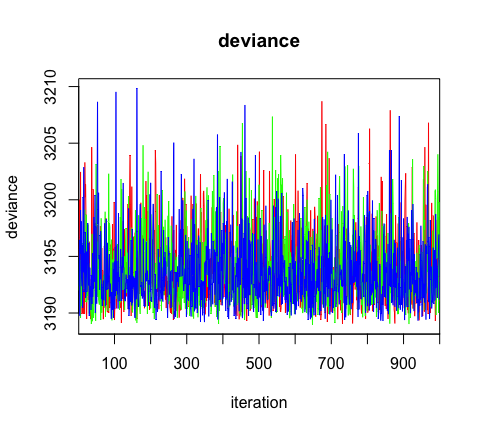

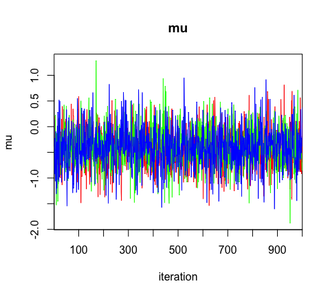

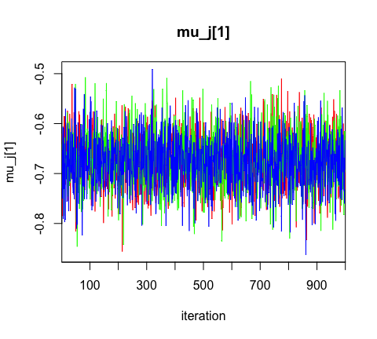

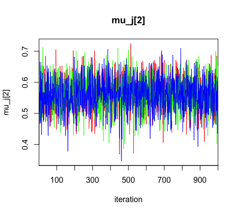

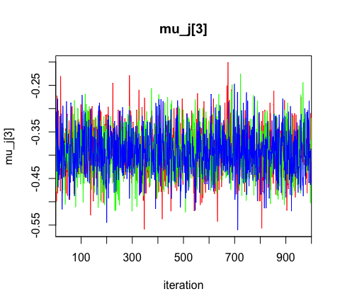

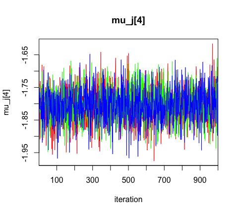

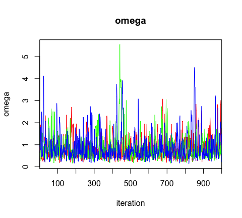

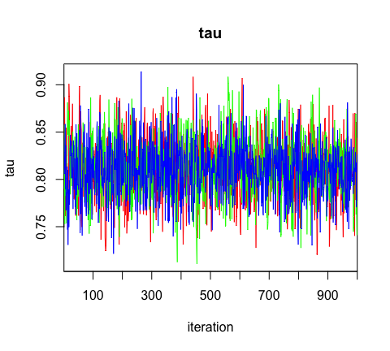

```r
traceplot(model_run)
```

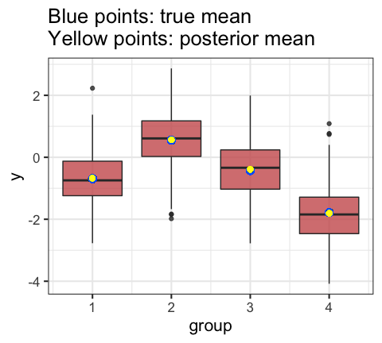

```r
# Create a plot of the posterior mean regression line
mu_j_pos = as.numeric(model_run$BUGSoutput$mean$mu_j)
mu_j_pos = rep(mu_j_pos, nj)

data.frame(y = y, group = group,
           muj = mu, mu_j_pos = mu_j_pos) %>%
  ggplot(aes(y = y, x = group, group = group)) +
  geom_boxplot(fill = "#CD5C5C", alpha = 0.8) +
  geom_point(aes(y = mu), colour = '#0066ff', size = 3) +
  geom_point(aes(y = mu_j_pos), colour = '#ffff1a', size = 2) +
  ggtitle(label = "Blue points: true mean \nYellow points: posterior mean") +
  theme_bw(16)
```

## Gibbs algorithm

**Algorithm 1**: GIBBS Sampling

**Data**: Target variable $y$, groups $j = 1,\dots,m$

**Result**: Posterior distributions for all parameters

**Initialisation**;

Hyper-parameters values for $\mu_{\mu}, \tau_{\mu}, \alpha, \beta, \alpha_{\omega}, \beta{\omega}$;

Number of groups $n$;

Number of observations $n=\sum_{j = 1}^{j}n_j$;

Number of iterations I;

- **for** i from 1 to I **do**:
  - sample $\mu$, $\tau$, and $\omega$ from their priors
  - **for** j in 1:m **do**:
    - sample $\mu_j$ from its prior
  - **end**
  - calculate the log full conditional density of $y$ using the sampled values as $l_{new}$
  - calculate the log full conditional density of $y$ using the previous sampled values as $l_{old}$
  - set $a = exp(l_{new} - l_{old})$
  - generate $u \sim U(0, 1)$
  - **if** $a > u$ **then**:
    - accept the sampled values **else**
    - set i+1 = i (?)
  - **end**
  - get the posterior distributions for $\mu_j$, $\mu$, $\tau$, $\omega$
- **end**